# *Workshop* **Using earth observation (EO) data products for environmental exposure assessment** *26 Feb - 1 March 2018, Basel Switzerland*

Alex Shtein

*Geography and Environmental Development*  
*Ben-Gurion University of the Negev, Israel*  
shtien@post.bgu.ac.il

## Outline

**Part a**- 27.02.18

- Using hdf files in R
- Using netcdf files (mainly climate data) in R

**Part b**- 28.02.18

Adding the following covariates for PM modeling:

- NDVI data
- Population density
- Roads data
- Land use proportion

## Link for downloading the data for the workshop

[data](https://drive.google.com/drive/folders/1dhzgZsmxsf0YQyh2pdmehPeD6OO3xlKL?usp=sharing)

## These are all the packages you will need to install for this part of the workshop:

```r
install.packages("gdalUtils")
install.packages("raster")
install.packages("rgdal")
install.packages("rgeos")
install.packages("plyr")
install.packages("magrittr")
install.packages("sp")
install.packages("ncdf4")
install.packages("reshape2")
install.packages("foreach")
install.packages("parallel")
install.packages("doParallel")
install.packages("velox")
install.packages("sf")
install.packages("leaflet")
```

## R Code file can be downloaded from:

[code file](https://github.com/alexandrashtein/Basel-workshop)

## a.1. HDF files

- Hdf is A file format that is getting increasingly common with geo-spatial gridded data.
- Hdf stands for hierarchical data format.
- For instance different AOD products and MODIS data have been delivered in hdf format.
- This data format has an architecture that makes it very convenient to store data of different kind in one file, but requires slightly more effort from the scientist to work with conveniently.

## Working with hdf files in Windows

- The rgdal package does not include hdf drivers in its pre-built binary.
- Data can therefore not be read directly from hdf into R (as object of class rasterLayer).
- A workaround is to convert the files externally to a different data format. Since you probably have **gdal** installed on your system (for example QGIS), you can use the command line utility **gdal_translate** to perform this operation.
- Geospatial Data Abstraction Library (GDAL) is a computer software library for reading and writing raster and vector geospatial data formats.
- One easy way to do that is by calling it directly from R, via the command line utility.

### Example for loading HDF file on Windows

#### This code converts the MAIAC AOD hdf files first into tiff files and finally into csv file

#### The example is for Israel area

```r
library(gdalUtils)
library(raster)
library(rgdal)

# If you do not have the gdal software installed, you will probable get an error message and won't be able to read hdf files
gdal_setInstallation()
x <- getOption("gdalUtils_gdalPath")

x[[1]]$path ## Look where is the GDAL is installed
```

```
## [1] "C:/OSGEO4~1/bin/"
```

```r
df <- x[[1]]$drivers # Table of all installed drivers
df[118:119,] # the hdf drivers
```

```
##           format_code read write update virtualIO subdatasets
## 118      HDF5-raster- TRUE FALSE  FALSE     FALSE        TRUE
## 119 HDF5Image-raster- TRUE FALSE  FALSE     FALSE       FALSE
##                            format_name
## 118 Hierarchical Data Format Release 5
## 119                       HDF5 Dataset
```

```r
# Set your working directory
setwd("G:/My Drive/Basel_workshop/files_for_code/")

# Get a list of sds names
sds <- get_subdatasets("MAIACAAOT.h03v03.20160120950.hdf")  # Returns subdataset names
sds
```

```
##  [1] "HDF4_EOS:EOS_GRID:MAIACAAOT.h03v03.20160120950.hdf:grid1km:Optical_Depth_047"
##  [2] "HDF4_EOS:EOS_GRID:MAIACAAOT.h03v03.20160120950.hdf:grid1km:Optical_Depth_055"
##  [3] "HDF4_EOS:EOS_GRID:MAIACAAOT.h03v03.20160120950.hdf:grid1km:AOT_Uncertainty"
##  [4] "HDF4_EOS:EOS_GRID:MAIACAAOT.h03v03.20160120950.hdf:grid1km:FineModeFraction"
##  [5] "HDF4_EOS:EOS_GRID:MAIACAAOT.h03v03.20160120950.hdf:grid1km:Column_WV"
##  [6] "HDF4_EOS:EOS_GRID:MAIACAAOT.h03v03.20160120950.hdf:grid1km:Injection_Height"
##  [7] "HDF4_EOS:EOS_GRID:MAIACAAOT.h03v03.20160120950.hdf:grid1km:AOT_QA"
##  [8] "HDF4_EOS:EOS_GRID:MAIACAAOT.h03v03.20160120950.hdf:grid1km:AOT_MODEL"
##  [9] "HDF4_EOS:EOS_GRID:MAIACAAOT.h03v03.20160120950.hdf:grid5km:cosSZA"
## [10] "HDF4_EOS:EOS_GRID:MAIACAAOT.h03v03.20160120950.hdf:grid5km:cosVZA"
## [11] "HDF4_EOS:EOS_GRID:MAIACAAOT.h03v03.20160120950.hdf:grid5km:RelAZ"
## [12] "HDF4_EOS:EOS_GRID:MAIACAAOT.h03v03.20160120950.hdf:grid5km:Scattering_Angle"
## [13] "HDF4_EOS:EOS_GRID:MAIACAAOT.h03v03.20160120950.hdf:grid5km:Glint_Angle"
```

```r
# R wrapper for gdal_translate - converts from hdf to tiff file
gdal_translate(sds[1], "test.tif")
## NULL

# Load the Geotiff created into R
r = raster("test.tif")
```

### Example - Converting multipile AOD MAIAC hdf files to csv files

```r
# Load libraries
library(raster)
library(rgdal)
library(rgeos)
library(gdalUtils)
library(plyr)
library(magrittr)
library(sp)
```

#### (1) A function that converts hdf to tiff files

```r
# This function is useful if you are running the code on Windows

read_hdf = function(file, n) {
  sds = get_subdatasets(file)
  f = tempfile(fileext = ".tif") # the tiff file is saved as a temporary file
  gdal_translate(sds[n], f)
  raster(f) # the ouptut is a raster file
}
```

#### (2) Load required files

```r
pol=readOGR(dsn="G:/My Drive/Basel_workshop/files_for_code","Project_border_latlon",verbose = FALSE)

# Define input Directory
aod_dir = "G:/My Drive/Basel_workshop/files_for_code" # working directory
# Reference grid directory
ref_grid = "G:/My Drive/Basel_workshop/files_for_code/MAIACLatlon.h03v03.hdf"
```

#### (3) Create a grid of locations for each grid cell

```r
###################################################################
# STEP 1 - Read the grid locations hdf files ######################
###################################################################

sds = get_subdatasets(ref_grid) # Get the sub-datasets of the refrence grid file

lon = read_hdf(ref_grid, which(grepl("latlon:lon", sds)))
lat = read_hdf(ref_grid, which(grepl("latlon:lat", sds)))

# Create 'row' and 'col' rasters
row = lon
row[] = rowFromCell(lon, 1:ncell(lon)) # Get the row and/or column number from a cell number of a Raster object
col = lon
col[] = colFromCell(lon, 1:ncell(lon))

# Combine to multi-band raster
grid = stack(row, col, lon, lat)
names(grid) = c("row", "col", "lon", "lat")

# Convert to data.frame
grid = as.data.frame(grid)

# Spatial subset according to our project area (Israel)
coordinates(grid) = ~ lon + lat
proj4string(grid) = "+proj=longlat +datum=WGS84 +no_defs +ellps=WGS84 +towgs84=0,0,0"
grid = grid[pol, ]

grid = as.data.frame(grid)

#####################
```

#### (4) Create a loop that converts all hdf files (from certain year) into final data.frame structure

```r
library(plyr)
library(magrittr)

for(year in 2014:2015) {
  # Read HDF files list from AOD directory
  setwd(file.path(aod_dir, year))

  files = list.files(pattern = "MAIACAAOT.h03v03.*\\.hdf$", recursive = TRUE) # note that MAIACTAOT is for TERRA data and MAIACAAOT is for AQUA data

  result = list()

  for(f in files) {

    # Read data
    sds = get_subdatasets(f)

    # Choose which subdatasets you want to retrieve from the hdf file
    Optical_Depth_047 = read_hdf(f, grep("grid1km:Optical_Depth_047", sds))
    Optical_Depth_055 = read_hdf(f, grep("grid1km:Optical_Depth_055", sds))
    AOT_Uncertainty = read_hdf(f, grep("grid1km:AOT_Uncertainty", sds))
    AOT_QA = read_hdf(f, grep("grid1km:AOT_QA", sds))
    RelAZ=read_hdf(f, grep("grid5km:RelAZ", sds))
    RelAZ=disaggregate(RelAZ, fact = 5)

    # Create rasters of rows and columns
    row = Optical_Depth_047
    row[] = rowFromCell(Optical_Depth_047, 1:ncell(Optical_Depth_047))
    col = Optical_Depth_047
    col[] = colFromCell(Optical_Depth_047, 1:ncell(Optical_Depth_047))

    # Stack all the raster together
    r = stack(row, col, Optical_Depth_047, Optical_Depth_055, AOT_Uncertainty, AOT_QA, RelAZ)
    names(r) = c("row", "col", "Optical_Depth_047","Optical_Depth_055", "AOT_Uncertainty", "AOT_QA","RelAZ")
    r = as.data.frame(r)

    # Join with 'grid' to add the location on each grid cell
    r = join(r, grid, c("row", "col"))
    r = r[!is.na(r$lon) & !is.na(r$lat), ]

    # Add filename
    r$date =
      f %>%
      strsplit("\\.") %>%
      sapply("[", 3) %>%
      substr(1, 7) %>%
      as.Date(format = "%Y%j")

    # Combine results
    result[[f]] = r

  }

  result = do.call(rbind.fill, result)
  setwd(file.path(aod_dir))
  saveRDS(result, sprintf("MAIACTAOT_Isr_%s.rds", year))
}
```

### Example for loading HDF file on Linux

```r
library(gdalUtils)
# First make sure you have GDAL software installed on your computer
# Get a list of sds names
sds <- get_subdatasets('full/path/filename.hdf')
# Any sds can then be read directly using the raster & readGDAL function
r <- raster(readGDAL(sds[1]))
```

### Staged 2&3 are the same for Linux

#### (4) Create a loop that converts all hdf files (from certain year) into final data.frame structure

```r
library(plyr)
library(magrittr)

# final = list()

for(year in 2014:2015) {
  # Read HDF files list from AOD directory
  setwd(file.path(aod_dir, year))

  files = list.files(pattern = "MAIACAAOT.h03v03.*\\.hdf$", recursive = TRUE) # note that MAIACTAOT is for TERRA data and MAIACAAOT is for AQUA data

  result = list()

  for(f in files) {

    # Read data
    sds = get_subdatasets(f)
    # Choose which subdatasets you want to retrieve from the hdf file
    Optical_Depth_047 = sds[grepl("grid1km:Optical_Depth_047", sds)] %>% readGDAL %>% raster
    Optical_Depth_055 = sds[grepl("grid1km:Optical_Depth_055", sds)] %>% readGDAL %>% raster
    AOT_Uncertainty = sds[grepl("grid1km:AOT_Uncertainty", sds)] %>% readGDAL %>% raster
    AOT_QA = sds[grepl("grid1km:AOT_QA", sds)] %>% readGDAL %>% raster

    row = Optical_Depth_047
    row[] = rowFromCell(Optical_Depth_047, 1:ncell(Optical_Depth_047))
    col = Optical_Depth_047
    col[] = colFromCell(Optical_Depth_047, 1:ncell(Optical_Depth_047))
    r = stack(row, col, Optical_Depth_047, Optical_Depth_055, AOT_Uncertainty, AOT_QA, RelAZ)
    names(r) = c("row", "col", "Optical_Depth_047","Optical_Depth_055", "AOT_Uncertainty", "AOT_QA","RelAZ")
    r = as.data.frame(r)

    # Join with 'grid' to add the location on each grid cell
    r = join(r, grid, c("row", "col"))
    r = r[!is.na(r$lon) & !is.na(r$lat), ]

    # Add filename
    r$date =
      f %>%
      strsplit("\\.") %>%
      sapply("[", 3) %>%
      substr(1, 7) %>%
      as.Date(format = "%Y%j")

    # Combine results
    result[[f]] = r

  }

  result = do.call(rbind.fill, result)
  setwd(file.path(aod_dir))
  saveRDS(result, sprintf("MAIACTAOT_Isr_%s.rds", year))
}
```

## a.2. Netcdf files

NetCDF is a widely used format for exchanging or distributing climate data, and has also been adopted in other fields, particularly in bioinformatics, and in other disciplines where large multidimensional arrays of data are generated.

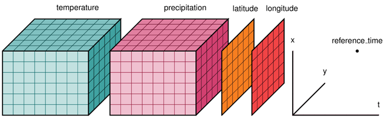

Netcdf file structure

NetCDF files are self-describing, in the sense that they contain metadata that describes what is contained in a file, such as the latitude and longitude layout of the grid, the names and units of variables in the data set, and “attributes” that describe things like missing value codes, or offsets and scale factors that may have been used to compress the data.

NetCDF files Originally developed for storing and distributing climate data, such as those generated by climate simulation or reanalysis models, the format and protocols can be used for other gridded data sets.

There are two versions of netCDF; netCDF3, which is widely used, but has some size and performance limitations, and netCDF4, which supports larger data sets and includes additional capabilities like file compression.

## Netcdf files in R

R has the capability of reading and writing (and hence analyzing) netCDF files, using the **ncdf** and **ncdf4** packages provided by David Pierce, and through other packages like **raster** and **RNetCDF**. The **ncdf4.helpers** package provides some additional tools.

### Example for importing PBL data from netCDF files (Israel)

The pbl netcdf files were downloaded from the ECMWF model: [pbl netcdf](http://apps.ecmwf.int/datasets/data/interim-full-daily/levtype=sfc/)

### Reading a netCDF data set using the ncdf4 package

```r
# Load the required packages\libraries
library(ncdf4)
library(magrittr)
library(raster)
library(reshape2)

# Define your working directory and load the ncdf file
setwd("G:/My Drive/Basel_workshop/files_for_code")
filename = "_grib2netcdf-atls15-95e2cf679cd58ee9b4db4dd119a05a8d-6JOEWD.nc"

# Open the NetCDF data set, and print some basic information.
nc = nc_open(filename)
class(nc)
```

```
## [1] "ncdf4"
```

```r
# print(nc)

# Get the the variable (pbl) and its attributes, and verify the size of the array.
pbl_array <- ncvar_get(nc,"blh")
dim(pbl_array)
```

```
## [1]     17     41 108840
```

```r
dlname <- ncatt_get(nc,"blh","long_name")
dlname
```

```
## $hasatt
## [1] TRUE
##
## $value
## [1] "Boundary layer height"
```

```r
dunits <- ncatt_get(nc,"blh","units")
dunits
```

```
## $hasatt
## [1] TRUE
##
## $value
## [1] "m"
```

```r
# In a netCDF file, values of a variable that are either missing or simply not available (i.e. ocean grid points in a terrestrial data set) are flagged using specific "fill values" (_FillValue) or missing values (missing_value), the values of which are set as attributes of a variable. In R, such unavailable data are indicated using the "NA" value.
fillvalue <- ncatt_get(nc,"blh","_FillValue")

# get longitude and latitude
lon <- ncvar_get(nc,"longitude")
nlon <- dim(lon)
head(lon)
```

```
## [1] 34.000 34.125 34.250 34.375 34.500 34.625
```

```r
lat <- ncvar_get(nc,"latitude")
nlat <- dim(lat)
head(lat)
```

```
## [1] 34.000 33.875 33.750 33.625 33.500 33.375
```

```r
print(c(nlon,nlat))
```

```
## [1] 17 41
```

```r
# Read time data
# Get the time variable and its attributes using the ncvar_get() and ncatt_get() functions, and list them, and also get the number of time steps using the dim() function.
time = ncvar_get(nc, "time")
nt <- dim(time)
nt
```

```
## [1] 108840
```

```r
# Understand the time units
# time is usually stored as the CF (Climate Forecast) "time since" format that is not usually human-readable.
# Print the time units string. Note the structure of the time units attribute. The object tunits has two components  hasatt (a logical variable), and tunits$value, the actual "time since" string.
tunits <- ncatt_get(nc,"time","units")
tunits
```

```
## $hasatt
## [1] TRUE
##
## $value
## [1] "hours since 1900-01-01 00:00:0.0"
```

```r
# Convert the time array into POSIXct class
origin = as.POSIXct("1900-01-01 00:00:0.0", tz = "GMT")
diffs = as.difftime(time, format = "%H", units = "hours")
time = origin + diffs

# Read values data & Create a rasterBrick object
r = brick(filename, varname = "blh")
dim(r)
```

```
## [1]     41     17 108840
```

```r
# Just for the example we will run the following lines on a small portion of the data
r <- r[[1:2]]
dim(r)
```

```
## [1] 41 17  2
```

```r
# To 'data.frame'
dat = as.data.frame(r, xy = TRUE) # xy=TRUE means that the spatial coordinates data will be kept
# dat[1:10,1:4]
names(dat) = c("lon", "lat", as.character(time[1:2], usetz = TRUE))
# dat[1:10,1:4]

# Reshape the data frame into a more suitable structure
dat = melt(
  dat,
  id.vars = c("lon", "lat"),
  variable.name = "time",
  value.name = "hpbl"
)

# Round & Remove rows with no 'hpbl' value
dat$hpbl = round(dat$hpbl)
dat = dat[!is.na(dat$hpbl), ]

# Filter time frame
dat$time = as.POSIXct(dat$time, tz = "GMT")
dat = dat[dat$time >= as.POSIXct("2003-01-01 00:00:00 GMT"), ]

# Write CSV
write.csv(dat, "ecmwf_hpbl_israel_2003_2016_new.csv", row.names = FALSE)
```

### Link for useful netcdf tutorial

[netcdf tutorial](http://geog.uoregon.edu/bartlein/courses/geog490/week04-netCDF.html)

# Part b- Calculating spatial covariates

**b.1.** NDVI data

**b.2.** Calculating road density

**b.3.** Calculating population density

**b.4.** Calculating the proportion of certain land use in each 1x1 cell grid

## b.1. Extract NDVI data from MODIS hdf files

```r
# Load libraries
library(magrittr)
library(sp)
library(rgdal)
library(rgeos)
library(raster)
library(parallel)
library(plyr)
library(sf)
library(gdalUtils)

setwd("G:/My Drive/Basel_workshop/files_for_code/MODIS_data")

# Prepare files list
files = list.files(
  pattern = "\\.hdf$",
  recursive = TRUE,
  full.names = TRUE
)

# Prepare years vector
files_split = strsplit(files, "\\.") # Split by '.'
dates = sapply(files_split, "[", 5) # Select date component from file name
dates = as.Date(dates, "A%Y%j")
years = format(dates, "%Y") %>% as.numeric # Characters 2-5 = Year
years
```

```
##  [1] 2000 2000 2000 2000 2000 2000 2000 2000 2000 2000 2001 2001 2001 2001
## [15] 2001 2001 2001 2001 2001 2001
```

```r
# This function is useful if you are running the code on Windows
read_hdf = function(file, n) {
  sds = get_subdatasets(file)
  f = tempfile(fileext = ".tif")
  gdal_translate(sds[n], f)
  raster(f)
}

###############################################################################################
# STEP 1 - covert from hdf files to raster files
###############################################################################################
## Note that in January months we get only 4 tiles (instead of five) in this area
## This should be considered and the missing tile should be completed, by finding the extent of the 5 tiles and complete the missing tile using the extend function

# This part takes time, therefore we will run only one year and one tile
y <- 2000
d <- as.character(unique(dates[years == y]))
current_files <-  files[dates == d[1]]
k <- current_files[1]
sds = get_subdatasets(k)
r = list()
r[[k]] = read_hdf(k, grep("1 km monthly NDVI", sds))
```

```r
# You can test later the following code that loops over multipile years
# Creates a Mosaic out of the different tiles for each month
# And saves the yearly as multi-band raster

for(y in 2000:2001) { # Loop 1: for each year

  # Empty raster stack
  result = stack()

  for(d in as.character(unique(dates[years == y]))) { # Loop 2: each day

    # Find the list of tiles for this date
    current_files = files[dates == d] # 'files' subset for given day

    # Empty list for 4 rasters
    r = list()

    # Reading tiles
    for(k in current_files) { # Loop 4: each tile

      sds = get_subdatasets(k) # Read current file
      r[[k]] = read_hdf(k, grep("1 km monthly NDVI", sds))
      # r[[k]] = sds[grepl("NDVI", sds)] %>% readGDAL %>% raster # Convert to raster- use this line instead if you work on Linux

    }

    # plot(r[[1]])

    # Save 1st tile to temporary object
    tmp = r[[1]]

    # If there is more than 1 tile...
    if(length(current_files) > 1) {

      # Loop through remaining 2, 3..., n tiles and mosaic
      for(j in 2:length(current_files)) {

        tmp = mosaic(tmp, r[[j]], fun = "mean") # Mosaic

      }

    }

    r = tmp
    names(r) = d # Set layer name

    result = stack(result, r)     # Adding another month as raster layer
  }

  # Save whole year raster
  saveRDS(result, paste0("G:/My Drive/Basel_workshop/files_for_code/MODIS_data/MOD13A3_", y, ".rds"))

}
```

```r
###############################################################################################
# STEP 2 - extract NDVI values from raster to the ECHO point grid
###############################################################################################
library(dplyr)
library(reshape2)
library(leaflet)

# Load the point Grid
grid = readOGR("G:/My Drive/Basel_workshop/files_for_code/grid_points_echo", "grid_boston", stringsAsFactors = FALSE, verbose = FALSE)

for(y in 2000:2001) {

  # Read raster
  setwd("G:/My Drive/Basel_workshop/files_for_code/MODIS_data")
  r = readRDS(paste0("MOD13A3_", y, ".rds"))
  r = r * 0.0001 * 0.0001 # scale factor

  ## We will crop the raster to smaller area just for the example
# Reproject 'grid' and 'AOI' to CRS of raster
  aoi <- readOGR("G:/My Drive/Basel_workshop/files_for_code", "boston_area", stringsAsFactors = FALSE, verbose = FALSE)
  aoi = spTransform(aoi, proj4string(r))
  grid = spTransform(grid, proj4string(r))
  # Crop raster
  r = crop(r, aoi, progress = "text")

  # Plot the NDVI raster
  pal <- colorNumeric(c("brown", "yellow", "darkgreen"), values(r),na.color = "transparent")

  leaflet() %>%
  addProviderTiles(providers$OpenStreetMap)%>%
  addRasterImage(r[[1,]],color=pal, opacity = 0.8) %>%
  addLegend(pal = pal, values = values(r),title = "NDVI")

  # Extract to grid
  tmp = extract(r, grid)
  tmp = as.data.frame(tmp)
  tmp$aodid = grid$aodid
  tmp = melt(tmp, id.vars = "aodid", variable.name = "date", value.name = "MO13A3_NDVI")
  tmp$date = tmp$date %>% as.character %>% as.Date(format = "X%Y.%m.%d")

  # Results table
  dat = expand.grid(
    aodid = grid$aodid,
    date = seq(
      as.Date(paste0(y, "-03-01")),
      as.Date(paste0(y, "-04-30")),
      by = 1
    ),
    stringsAsFactors = FALSE
  )

  # Join
  dat$month = format(dat$date, "%m")
  tmp$month = format(tmp$date, "%m")
  dat = dplyr::left_join(dat, tmp[, c("aodid", "month", "MO13A3_NDVI")], c("aodid", "month"))
  dat$month = NULL

  # Write
  setwd("G:/My Drive/Basel_workshop/files_for_code/MODIS_data/")
  saveRDS(dat, paste0("./results/grid_MO13A3_NDVI_", y, ".rds"))

}
```

## b.2. Calculating road density

```r
###############################################################################
# Major road density (length / km^2)

library(magrittr)
library(sp)
library(rgdal)
library(rgeos)
library(raster)
library(parallel)
library(plyr)
library(sf)

# Load roads data
setwd("G:/My Drive/Basel_workshop/files_for_code")
roads_major = st_read("./roads_data", "NEMIA_roadsmajor_Boston_area")
## Reading layer `NEMIA_roadsmajor_Boston_area' from data source `G:\My Drive\Basel_workshop\files_for_code\roads_data' using driver `ESRI Shapefile'
## Simple feature collection with 1 feature and 1 field
## geometry type:  MULTILINESTRING
## dimension:      XY
## bbox:           xmin: -71.27122 ymin: 42.20201 xmax: -70.90531 ymax: 42.52689
## epsg (SRID):    4326
## proj4string:    +proj=longlat +datum=WGS84 +no_defs
# Transform the coordinate system of the roads layer
roads_major = st_transform(roads_major, "+proj=laea +lat_0=45 +lon_0=-100 +x_0=0 +y_0=0 +a=6370997 +b=6370997 +units=m +no_defs")

# Load polygon grid of boston area
grid_1km = st_read("./grid_square_1km", "grid_square_1km_boston", stringsAsFactors = FALSE)
## Reading layer `grid_square_1km_boston' from data source `G:\My Drive\Basel_workshop\files_for_code\grid_square_1km' using driver `ESRI Shapefile'
## Simple feature collection with 737 features and 6 fields
## geometry type:  POLYGON
## dimension:      XY
## bbox:           xmin: -71.27276 ymin: 42.20031 xmax: -70.89984 ymax: 42.52692
## epsg (SRID):    4326
## proj4string:    +proj=longlat +datum=WGS84 +no_defs
grid_1km_us = st_transform(grid_1km, "+proj=laea +lat_0=45 +lon_0=-100 +x_0=0 +y_0=0 +a=6370997 +b=6370997 +units=m +no_defs")

########################################################

# Set parallel
library(foreach)
library(doParallel)
cl = makeCluster(detectCores(4))
registerDoParallel(cl)

# Calculate Road density & distance to nearest road
# Note that the output of this process is a list
# The result of each iteration is stored as a list component

roads_lengths = foreach(
    i = 1:nrow(grid_1km_us),
    .packages = c("sf", "magrittr")
  ) %dopar% {
  majorroads_length_km_km2 = st_intersection(roads_major, grid_1km_us[i, ])
  majorroads_length_km_km2 = if(nrow(majorroads_length_km_km2) > 0) {
    majorroads_length_km_km2 %>%
      st_length %>%  # Length of intersecting roads
      as.numeric %>%
      divide_by(1000)
    } else 0 # No intersection = 0

  # Calculate distance to major roads
  nearest_majorroad_dist_km =
    st_distance(roads_major, grid_1km_us[i, ]) %>%
    as.numeric %>%
    divide_by(1000)

  c(
    majorroads_length_km_km2,
    nearest_majorroad_dist_km
    )

}

stopCluster(cl)

# Add the columns back to the square grid
grid_1km$majorroads_length_km_km2 = sapply(roads_lengths, "[", 1)
grid_1km$nearest_road_dist_km = sapply(roads_lengths, "[", 2)

dat = grid_1km
st_geometry(dat) = NULL # sf object to data frame

# Save result
saveRDS(dat, "grid_1km_roads.rds")
```

## b.3. Adding population density data

```r
# Load libraries
library(magrittr)
library(sp)
library(rgdal)
library(rgeos)
library(raster)
library(plyr)
library(velox)
```

### Add population data from raster to square grid layer

```r
setwd("G:/My Drive/Basel_workshop/files_for_code") # Set working directory
# Load AOI and grid data
aoi = readOGR(dsn=".", "boston_area", verbose = FALSE)
grid_1km = readOGR("./grid_square_1km","grid_square_1km_boston", verbose = FALSE) # square grid

# Load Population density raster
r = raster("./pop_dens/gpw-v4-population-density-adjusted-to-2015-unwpp-country-totals_2010.tif")

# Reproject 'grid' and 'AOI' to CRS of raster
grid_1km_proj = spTransform(grid_1km, proj4string(r))
aoi = spTransform(aoi, proj4string(r))

# Crop raster
r = crop(r, aoi, progress = "text")

# Plot population raster
# define your own color ramp
pal <- colorNumeric(c("white", "black"), values(r),
                    na.color = "transparent")
# plot
leaflet() %>%
  addProviderTiles(providers$OpenStreetMap)%>%
  addRasterImage(r,color=pal, opacity = 1) %>%
  addLegend(pal = pal, values = values(r),title = "population density")
```

[interactive chart not shown]

```r
# Extract
# Velox is an R package for performing fast extraction and manipulation operations on geographic raster data.
# velox is intended to be used together with the raster package, to which it provides a straightforward interface.

vx = velox(r) # 'RasterLayer' to 'velox' object
f = function(x) mean(x, na.rm = TRUE)
x = vx$extract(sp = grid_1km_proj, fun = f) # 'Fast' extraction method
grid_1km$pop_dens_2015 = x[, 1] # Add new column in 'grid_1km' layer

# Save the result and clean memory
grid_1km_t = as.data.frame(grid_1km)
saveRDS(grid_1km_t, "G:/My Drive/Basel_workshop/files_for_code/pop_dens/grid_1km_pop_dens.rds")
```

## b.4. Calculating the proportion of certain land use in each 1x1 cell grid

```r
# Load libraries
library(magrittr)
library(sp)
library(rgdal)
library(rgeos)
library(raster)
library(plyr)
library(velox)
```

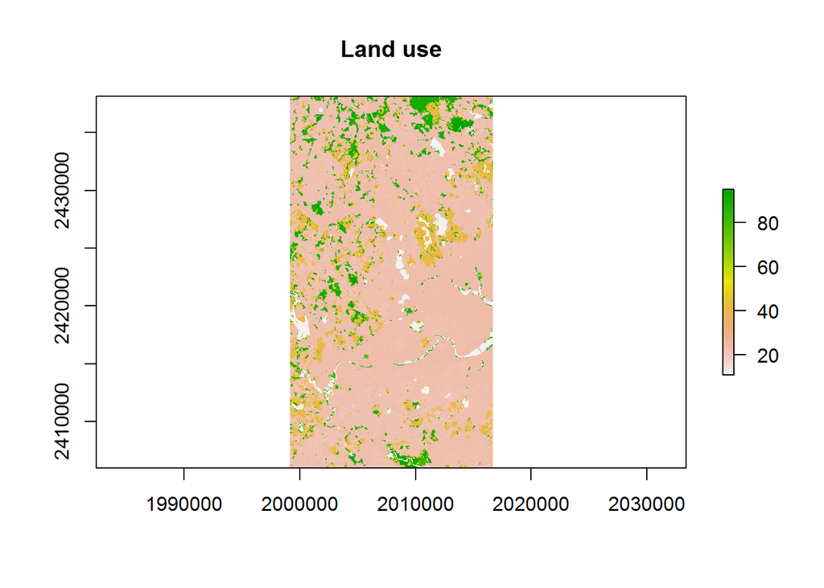

```r
###############################################################################
setwd("G:/My Drive/Basel_workshop/files_for_code") # Set working directory

# Load AOI and grid data
aoi = readOGR(dsn=".", "boston_area", verbose = FALSE)
grid_1km = readOGR("./grid_square_1km","grid_square_1km_boston", verbose = FALSE) # square grid

# Read Land Cover raster
lu = raster("./land_use/nlcd_2011_boston_area.img")

# Reproject 'grid' and 'AOI' to CRS of raster
grid_1km_proj = spTransform(grid_1km, proj4string(lu))
aoi = spTransform(aoi, proj4string(lu))

# Crop raster
lu = crop(lu, aoi, progress = "text")
plot(lu, main="Land use")
```

### Example for calculating proportion of forested area

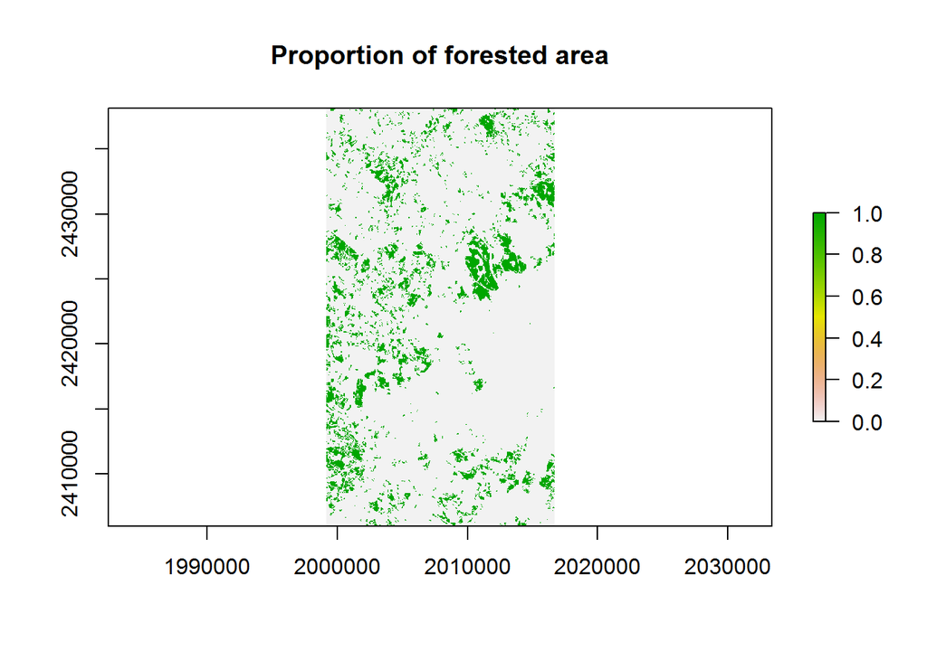

```r
# Extract land cover to 'grid'
r = lu %in% c(41, 42, 43) # Reclassify

plot(r, main="Proportion of forested area")
```

```r
vx = velox(r) # 'RasterLayer' to 'velox' object
f = function(x) mean(x, na.rm = TRUE)
x = vx$extract(sp = grid_1km_proj, fun = f) # 'Fast' extraction method
grid_1km$forestProp_1km = x[, 1] # Add new column in 'grid_1km' layer

# Save the result and clean memory
grid_1km_t=as.data.frame(grid_1km)
saveRDS(grid_1km_t, "G:/My Drive/Basel_workshop/files_for_code/land_use/grid_1km_forestProp_1km.rds")
```